# Actividad 2 Modulo 1

2024-04-12

#### **Equipo 1**

- Gabriela Cantú Sánchez A01735256
- Alexa Mariana Marin Villar A00831342
- Ana Estefanía López Alanis A01284416
- Astrid Paola Gonzalez Diaz A00830114

## **Introducción**

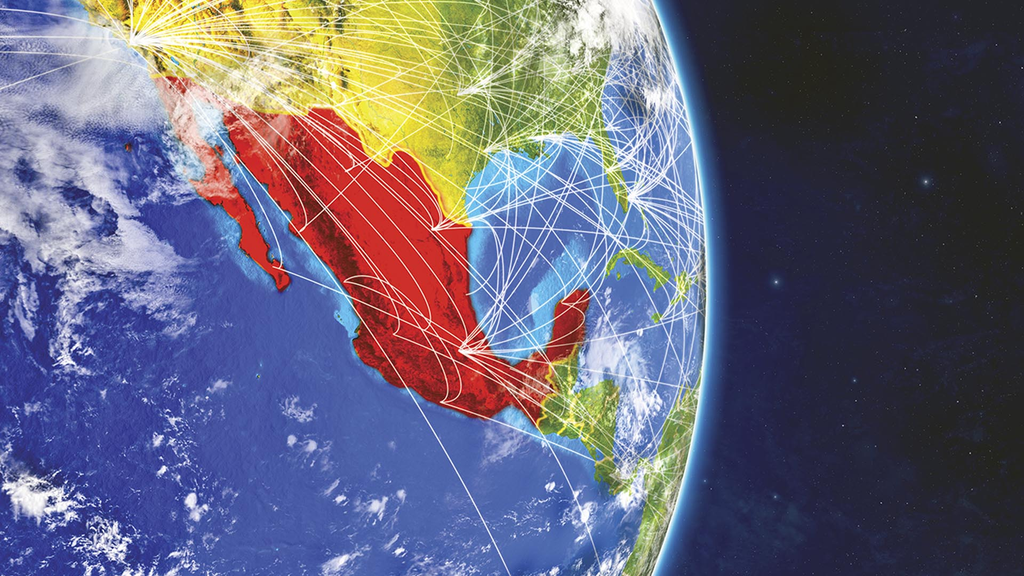

### Location Intelligence y Análisis Espacial

La inteligencia de localidad permite obtener hallazgos derivados de herramientas de análisis así como visualizaciones de manera geoespacial, esto puede incluir el uso de información específica con características de localidad como datos demográficos, tráfico, medio ambiente, economía, clima o incluso análisis sociales (ESRI, s.f)[^1]. Es una metodología utilizada para resolver preguntas de índole espacial que haciéndolo así una parte integral del problema a analizar (Carto, s.f)[^2].  
Como se expuso anteriormente, la inteligencia de localidad y el análisis espacial se presentan de la mano puesto el análisis espacial es completamente necesario para cumplir con el objetivo del tipo de inteligencia de localidades.

## **Transformación de datos**

### **Exploración de variables importantes**

A través de la exploración de estas varaibles se podrá visualizar si siguen una distribución normal, de no ser así se haran ajustes para que no se afecten los resultados del modelo. Sería importante considerar un ajuste en la variable de population density, lq primary y employment.

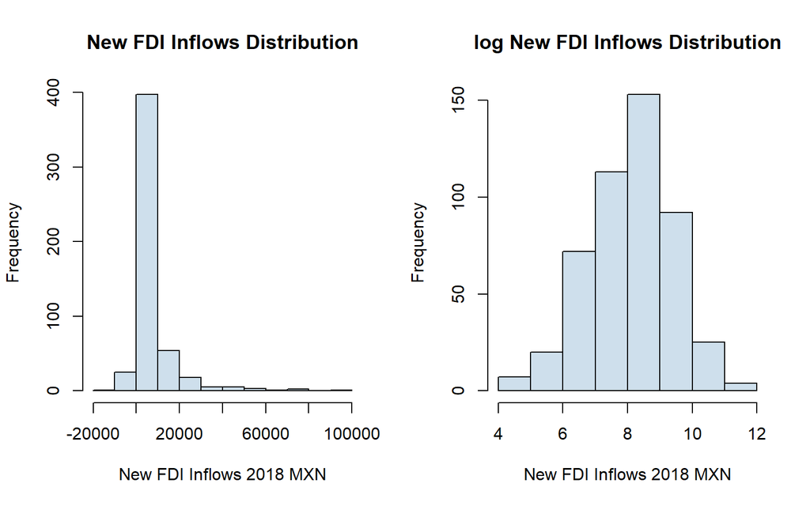

```r
nearshoring<- nearshoring %>% mutate(log_newFDI_real=log(new_fdi_real_mxn))
```

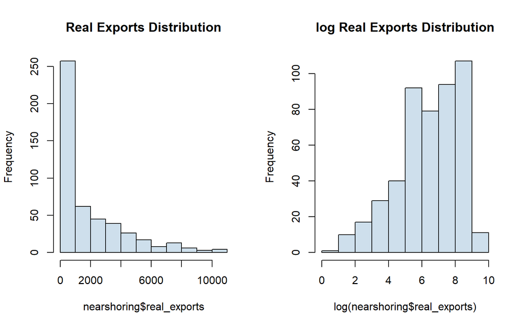

```r
nearshoring<- nearshoring %>% mutate(log_real_exports=log(real_exports))
```

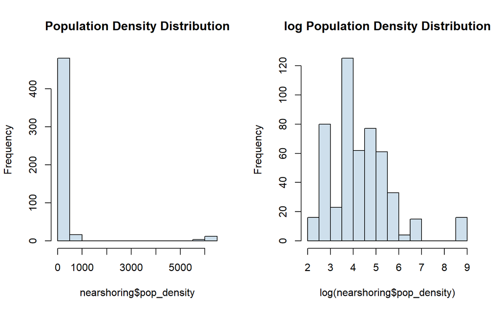

```r
nearshoring<- nearshoring %>% mutate(log_pop_density=log(pop_density))
```

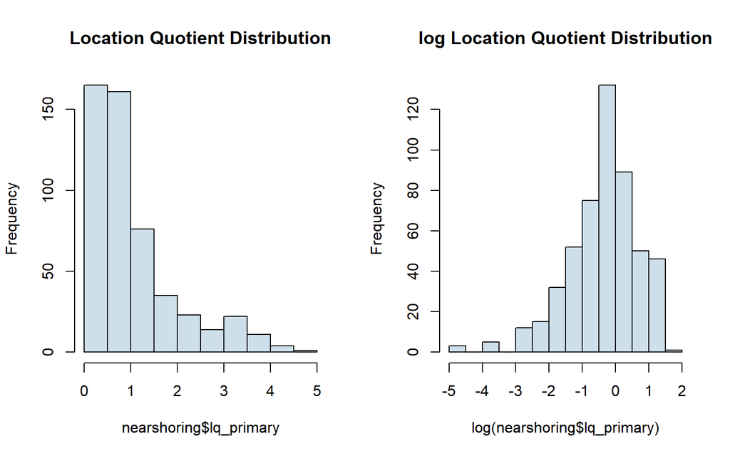

```r
nearshoring<- nearshoring %>% mutate(log_lq=log(lq_primary))
```

## **Creación de datos Panel**

```r
nearshoring_pd<- pdata.frame(nearshoring, index = c("state", "year"))
nearshoring_pd<- nearshoring_pd %>% dplyr::select(-state, -year)
#head(nearshoring_pd)
```